# Programadores profesionales

Además, el p-valor de la prueba F de Fisher es también menor que la significancia de 0.1, por lo que básicamente se rechaza la hipótesis nula:
$$H_0: \text{El modelo no explica
nada}$$
Ahora podemos analizar las gráficas de la estructuras de los residuos y su distribución utilizando la función plot con el modelo como parámetro.

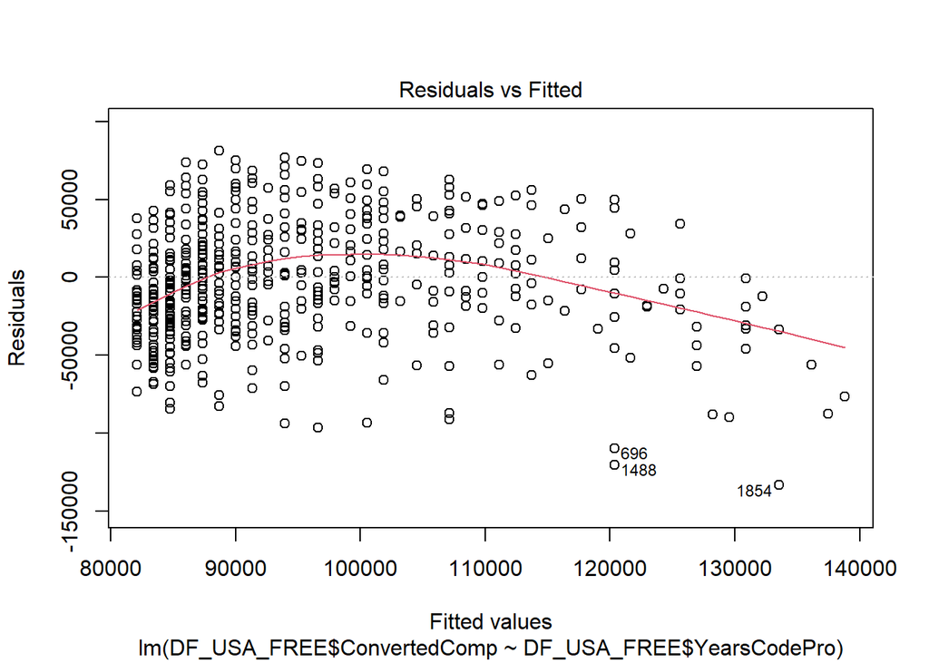

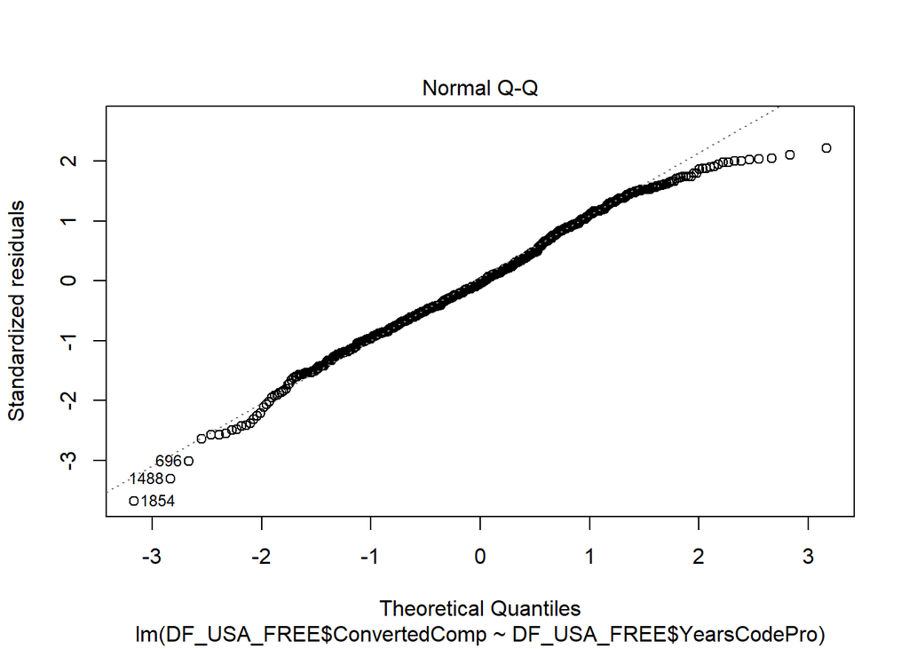

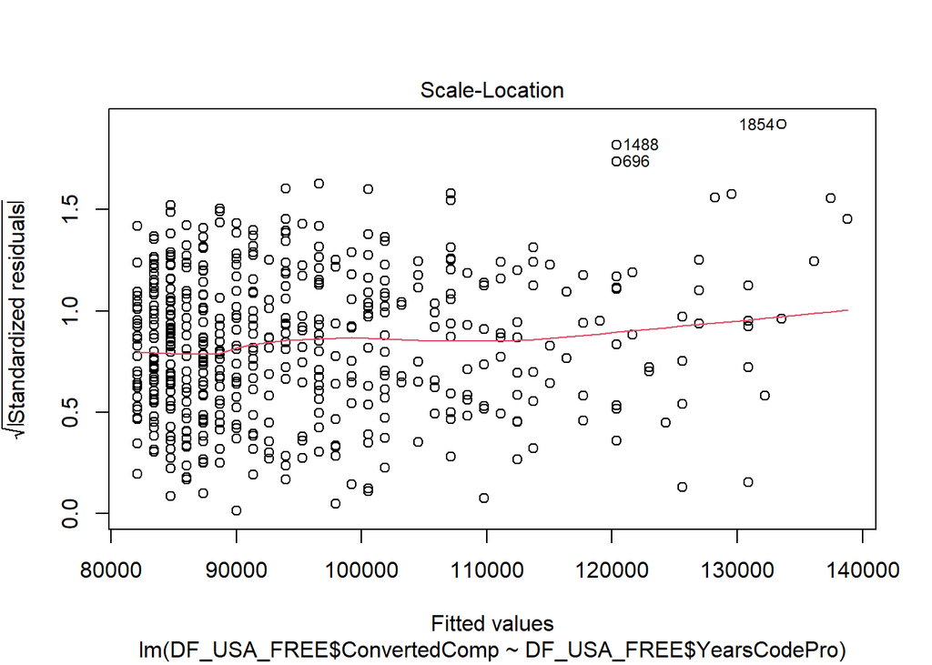

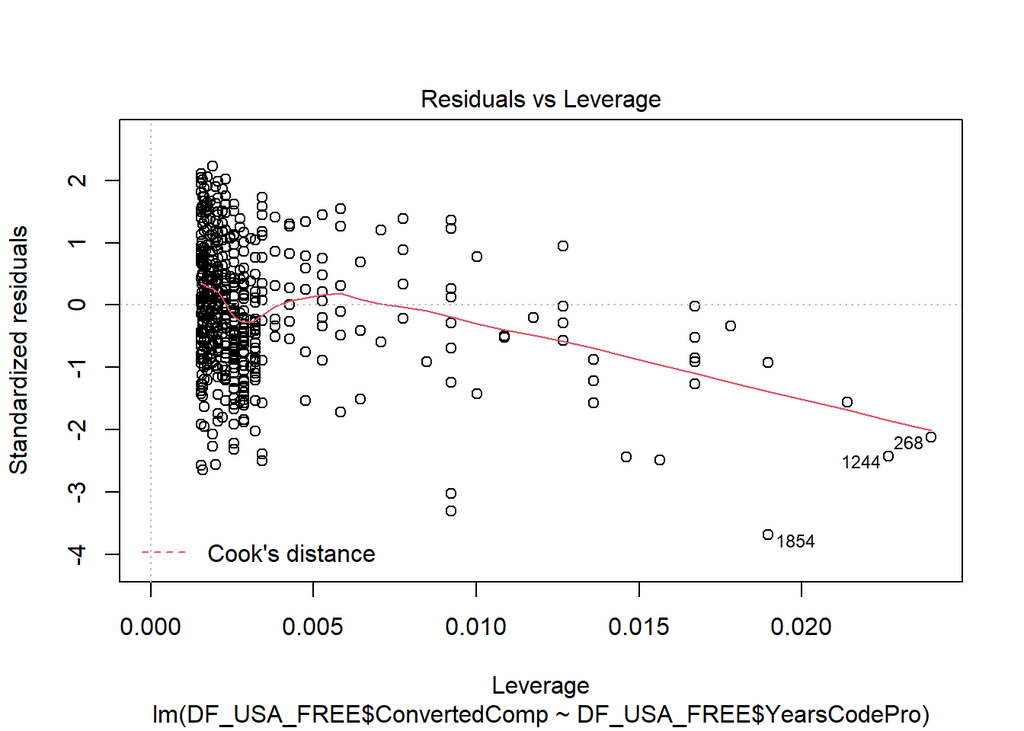

```r
plot(lm(DF_USA_FREE$ConvertedComp ~ DF_USA_FREE$YearsCodePro))
```

Se puede apreciar que las gráficas de residuo a excepción de la segunda, acreditan que el modelo no explica fuertemente la relación entre variables, esto se puede acreditar por la misma correlación que se obtuvo anteriormente y el ajuste que obtuvimos. Comprobando que en Estados Unidos la experiencia laboral no tiene un impacto notable sobre la remuneración que reciben los programadores. Sin embargo, es necesario resaltar que hay datos en los bordes de las gráficas, con un peso enorme sobre el modelo, lo que tiene mucha influencia sobre el ajuste del modelo.

#Latinoamérica

```r
summary(lm(DF_LA_FREE$ConvertedComp ~ DF_LA_FREE$YearsCodePro))
```

```
Call:
lm(formula = DF_LA_FREE$ConvertedComp ~ DF_LA_FREE$YearsCodePro)

Residuals:
   Min     1Q Median     3Q    Max
-48835  -9672  -5434   3349 124540

Coefficients:
                        Estimate Std. Error t value Pr(>|t|)
(Intercept)              12018.5     1293.4   9.292   <2e-16 ***
DF_LA_FREE$YearsCodePro   1221.9      123.8   9.871   <2e-16 ***
---
Signif. codes:  0 '***' 0.001 '**' 0.01 '*' 0.05 '.' 0.1 ' ' 1

Residual standard error: 20100 on 509 degrees of freedom
  (669 observations deleted due to missingness)
Multiple R-squared:  0.1607,    Adjusted R-squared:  0.159
F-statistic: 97.45 on 1 and 509 DF,  p-value: < 2.2e-16
```

$$H_0: \text{El coeficiente es 0}$$
Y también rechazamos la hipótesis nula del modelo gracias al p valor de la prueba F.

Además, el p-valor de la prueba F de Fisher es también menor que la significancia de 0.1, por lo que básicamente se rechaza la hipótesis nula:
$$H_0: \text{El modelo no explica
nada}$$
Ahora podemos analizar las gráficas de la estructuras de los residuos y su distribución utilizando la función plot con el modelo como parámetro

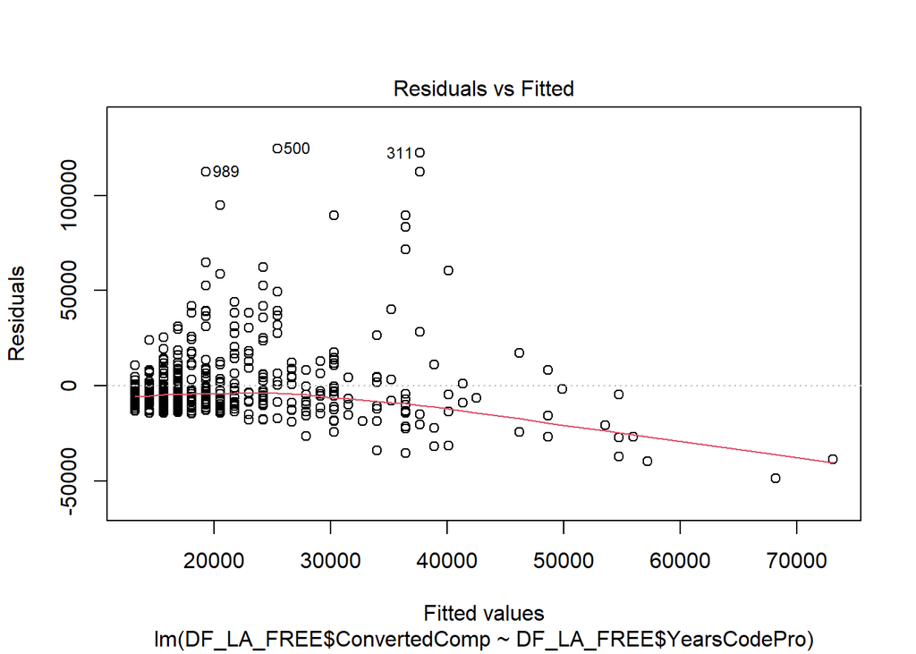

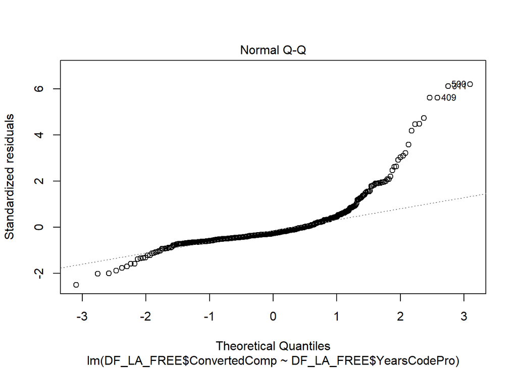

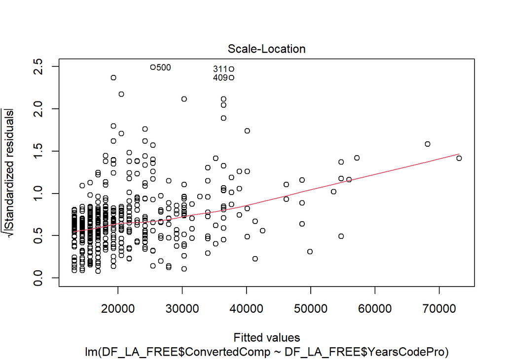

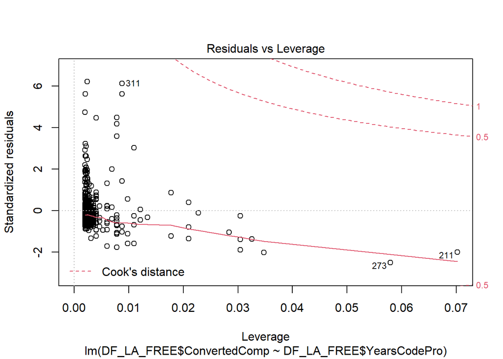

```r
plot(lm(DF_LA_FREE$ConvertedComp ~ DF_LA_FREE$YearsCodePro))
```

#### ¿Cuál es la probabilidad de que un desarrollador profesional de Estados Unidos o de América latina tenga un sueldo anual “estándar”?

Anteriormente se definió (utilizando fuentes bibliográficas y el gráfico original) una variable booleana que nos permite definir si un programador posee un sueldo anual “estándar” o no. Utilizando esta variable se puede definir otra variable aleatoria discreta que se distribuye en una Bernoulli p. Cuando un programador gane un sueldo estándar, será considerado un éxito, y cuando gane más del estándar será un fracaso. Se calcula la probabilidad de éxito par ambas regiones:

```r
totalUSA <- nrow(DF_FT_USA)
totalUSA_std <- nrow(DF_FT_USA[DF_FT_USA$isStandard_usa == TRUE,])
totalLA <- nrow(DF_FT_LA)
totalLA_std <- nrow(DF_FT_LA[DF_FT_LA$isStandard_la == TRUE,])
round(dbern(1, totalUSA_std/totalUSA),2)
```

```
[1] 0.84
```

```r
round(dbern(1, totalLA_std/totalLA),2)
```

```
[1] 0.91
```

Se puede observar que, la probabilidad de que al elegir un programador profesional en Estados Unidos este gane un sueldo considerado estándar es de 0.84. Mientras que si hacemos este experimento en América Latina, la probabilidad es de 0.91. Esto indica que quizá el sueldo estándar, que se obtuvo de la fuente bibliográfica y se corroboró con el gráfico, podría estar un poco por debajo de un supuesto sueldo estándar real.

#### ¿Cuál es la probabilidad de que un desarrollador profesional de Estados Unidos o de América latina trabaje en una empresa que cuente con un buen proceso de incorporación?

A continuación se utilizará la variable ordinal “proceso de incorporación” que tiene 3 categorías para indicar si es que el proceso de incorporación de la empresa en dónde trabajan los programadores profesionales tienen un buen proceso de incorporación. Estas son: “Sí”, “No” y “¿Cuál proceso?. Se tomará como una variable aleatoria si tiene una distribución Bernoulli p, donde se considerará como éxito cuando un trabajador responde”Sí” a la pregunta si es que proceso de incorporación de su empresa es bueno, y se tomará como fracaso cualquier otra respuesta (No o ¿Cuál proceso?).

```r
totalUSA_yes <- nrow(DF_USA[DF_USA$NEWOnboardGood == "Yes" & !is.na(DF_USA$NEWOnboardGood),])
totalUSA <- nrow(DF_USA[!is.na(DF_USA$NEWOnboardGood),])
totalLA_yes <- nrow(DF_LA[DF_LA$NEWOnboardGood == "Yes" & !is.na(DF_LA$NEWOnboardGood),])
totalLA <- nrow(DF_LA[!is.na(DF_LA$NEWOnboardGood),])
round(dbern(1, totalUSA_yes/totalUSA),2)
```

```
[1] 0.5
```

```r
round(dbern(1, totalLA_yes/totalLA),2)
```

```
[1] 0.44
```

Se puede apreciar que la probabilidad de que al escoger un programador en Estados Unidos o en América Latina la empresa donde trabaja tenga un buen proceso de incorporación es bastante similar. Se puede extender este experimento para aplicar una distribución binomial, y mostrar las probabilidades de obtener de 1 a 10 programadores cuya empresa tenga un buen proceso de incorporación al escogerlos de un grupo de 10.

```r
data.frame("n_éxito"=c(1:10), "prob" = round(dbinom(c(1:10), 10, totalUSA_yes/totalUSA),3))
```

| n_éxito | prob |
| --- | --- |
| 1 | 0.010 |
| 2 | 0.044 |
| 3 | 0.118 |
| 4 | 0.205 |
| 5 | 0.246 |
| 6 | 0.205 |
| 7 | 0.117 |
| 8 | 0.044 |
| 9 | 0.010 |
| 10 | 0.001 |

Se puede ver que en Estados unidos lo más probable es que 5 programadores de los 10 elegidos trabajen en una empresa con un buen proceso de incorporación.

```r
data.frame("n_éxito"=c(1:10), "prob" = round(dbinom(c(1:10), 10, totalLA_yes/totalLA),3))
```

| n_éxito | prob |
| --- | --- |
| 1 | 0.024 |
| 2 | 0.085 |
| 3 | 0.177 |
| 4 | 0.243 |
| 5 | 0.228 |
| 6 | 0.149 |
| 7 | 0.067 |
| 8 | 0.020 |
| 9 | 0.003 |
| 10 | 0.000 |

Por otro lado, en América Latina, lo más probable sea que 4 de los 10 trabajen en una organización con un buen acoplamiento.

## Conclusiones

En base al previo análisis de variables, se puede corroborar que sí existen diferencias tanto en el aspecto educativo y laboral entre programadores profesionales de América Latina y Estados Unidos.

Una de las diferencias más relevantes en el aspecto educativo es que existe un mayor ritmo de aprendizaje de lenguajes de programación en América Latina en comparación con Estados Unidos, ya que en promedio la frecuencia de aprendizaje más común en Estados Unidos es un nuevo lenguaje por año, mientras que en América Latina es un nuevo lenguaje cada pocos meses. Además, la edad a la que los programadores profesionales desarrollaron su primer programa, en promedio, es menor en Estados Unidos que en América Latina. Esto puede ser el resultado de un mayor desarrollo tecnológico en Estados Unidos, por lo que la necesidad o motivación por desarrollar un programa surgió antes en la población de dicho país que en América Latina. Asimismo, existen diferencias mínimas en este aspecto, como por ejemplo el grado educativo de los programadores profesionales, ya que tanto en Estados Unidos como en América latina, la mayoría tiene licenciatura, con una diferencia de aproximadamente diez por ciento más a favor de Estados Unidos, y esto quizá se deba a un mejor nivel de educación que América Latina.

Dentro del aspecto laboral, se puede concluir que existe mejor igualdad de oportunidades laborales en Estados Unidos, ya que la cantidad de programadores profesionales de sexo femenino es aproximadamente el doble en comparación con América Latina. Asimismo, el tamaño de la organización o empresa en la que laboran los programadores profesionales es mayor en Estados Unidos (10000 empleados o más) en comparación con América Latina (20 a 99 empleados). Este resultado es de esperarse ya que Estados Unidos cuenta con empresas tecnológicas y que desarrollan software líderes a nivel mundial como Microsoft, Apple, Facebook, entre otras, que a su vez cuentan con una gran cantidad de empleados.

### Bibliografía

- BBC new. (2019). Cuáles son los países donde la gente trabaja más y menos horas semanales (y qué quieren cambiar en Chile). Recuperado de https://www.bbc.com/mundo/noticias-49411425.
- Evalart (2019). Cuánto ganan los desarrolladores en América Latina. Recuperado de https://evalart.com/es/blog/cuanto-ganan-los-desarrolladores-en-america-latina/#:~:text=Por%20%C3%BAltimos%20se%20encuentran%20los,ganar%20hasta%203.170%2C00%20USD.
- Internal Revenue Service. (2021). Identifying Full-time Employees. Recuperado de https://www.irs.gov/affordable-care-act/employers/identifying-full-time-employees
- ZipRecruiter (2020). Software Developer Salary. Recuperado de https://www.ziprecruiter.com/Salaries/Software-Developer-Salary